# STAT 408 Lecture 2: Quarto

Jess Kunke

Tue 20 Jan 2026

# Quarto: text, code, output

## What is Quarto?

Quarto allows you to write documents that combine text, your code, and output/results from that code

- Like R Markdown but for lots of languages (Python, Julia, …)
- R Markdown will continue to be maintained, but new development will supposedly be in Quarto
- Myriad formats: PDFs, Word, slides, books, websites, journal articles, Jupyter notebooks, …

Why Quarto?

- Reproducible! (code, output, and report all in one document)
- Can switch between formats and audiences relatively easily

## Creating a new Quarto doc

For now, let’s choose HTML format

Click Create instead of Create Empty Document to get a template/example document

Getting oriented:

- Visual editor vs source editor
- YAML header is the part between `---` and `---`, and it sets up global options for the document formatting

## Jargon: a comment on “markdown”

Markdown is actually a kind of markup language

Markup languages specify document structure and formatting

Examples: HTML, LaTeX, Markdown, YAML

Quarto uses two markup languages:

- YAML in the header and code chunk options
- (Pandoc) Markdown in the body of the document

## YAML header

Let’s practice a bit with the YAML header:

- Change the title to “Lecture 2 notes”
- Set the author to your name using the `author` option
- Set the date to today’s date using the `date` option
- Try changing the format to html, pdf, and Word (`format: docx`), and render each time

## Activity 1: Markdown (text) formatting

[R4DS2e Section 28.4](https://r4ds.hadley.nz/quarto.html#sec-source-editor) has some helpful examples of markdown formatting

[Quarto documentation](https://quarto.org/docs/authoring/markdown-basics.html) provides additional options

**Activity 1:** make a basic CV (yours or imaginary)

- Start by making a new Quarto document
- Make the title the person’s name and leave out the `author` field
- Create headings for education, employment, and skills
- Add at least one bulleted list and one numbered list
- Include a link to the person’s website or LinkedIn
- Use italics and bold somewhere in the document
- If you have time, look up how to add a footnote, image, or table

## Code chunks, local options, create new chunk

Let’s return to your original template document (or make a new one)

Compare the code chunks between the .qmd file and the rendered document: what’s different about how the two chunks are rendered, and why?

What happens if you replace the code chunk option `echo: false` with the following?

- `output: false`
- `include: false`
- `eval: false`
- `echo:false` (no space)
- `echo: False` (caps)

Create a new, empty code chunk using the keyboard shortcut *Control+Alt+I* (Windows and Linux) or *Command+Option+I* (Mac). “I” is for insert.

Which options hide the code? Hide the results of the code? Hide both? Don’t run the code at all? Why might you not want to run a chunk of code?

## Activity 2: Make a tutorial

Option 1: Reproduce the text, code, and formatting of [R4DS2e Section 1.3](https://r4ds.hadley.nz/data-visualize.html#sec-ggplot2-calls)

Option 2: Teach someone else how to make a simple plot of the `penguins` dataset using **ggplot**

Either way:

- Tell your audience how to load the packages they’ll need
- Hide the messages that the `library` commands print out
- Use `code-formatted text` whenever you talk about a function/command in the body of your text
- Give the tutorial an appropriate title and author
- Use today’s date as the date by setting [`date: today`](https://quarto.org/docs/reference/dates.html#date-parsing)
- Check out [date formats](https://quarto.org/docs/reference/dates.html#using-a-date-format) to make it print the date in a particular format you like
- Play with (1) hiding the code but not its output and (2) showing the code without running it

# Code style + basics

## Assignment

To assign an object `x` a value of `2`, use either `=` or `<-`:

- For readability, include a space on either side of the operator
- Stay consistent with which operator you use in a given document
- Only `<-` works for sufficiently old code

## Naming objects

- Object names should only include letters, numbers, periods `.`, and underscores `_`
- Make names descriptive (e.g. `bill_length` and not `xx` or `var1`)
- Use snake case (words separated by underscores, e.g. `bill_length`) for readability
- Names are case-sensitive (`bill_length` and `Bill_length` are two different objects)

# Data transformation

## More about **tidyverse**

**tidyverse** is actually a suite/bundle of 9 packages often used together

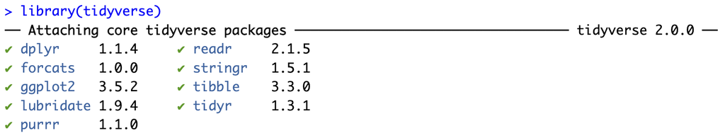

Four key **tidyverse** packages we’ll start with in Unit 1 of this course:

- **readr** to import data
- **tidyr** to tidy data
- **dplyr** to transform data
- **ggplot2** to visualize data

## More about **tidyverse**

**tidyverse** is actually a suite/bundle of 9 packages often used together

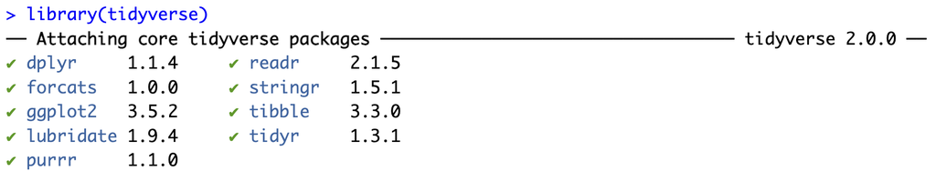

Four key **tidyverse** packages we’ll start with in Unit 1 of this course:

- **readr** to import data
- **tidyr** to tidy data
- **dplyr to transform data**
- **ggplot2 to visualize data**

## Data transformation

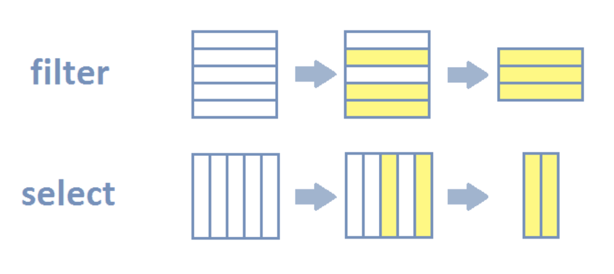

## Data transformation

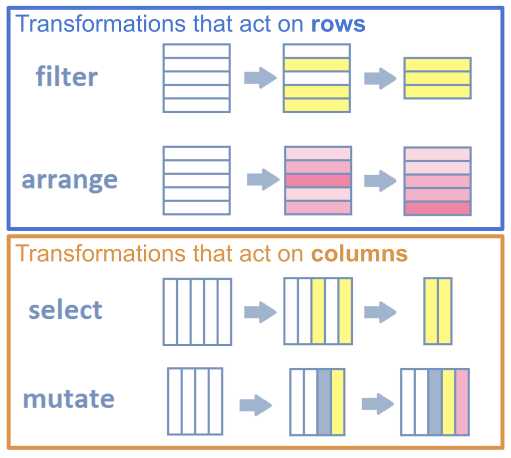

## Next time, and resources

Homework 1 due on Gradescope by start of class Thursday

- Read and code along through R4DS2e Section 1.4
- Create a new Quarto document, write out the instructions for and your solutions to the exercises in R4DS2e Section 1.4.3
- See Homework 1 Gradescope assignment for details!

Thursday in class: Lab 2 on data transformation

- We’ll be working through parts of Chapter 3 of R4DS2e

Posit (formerly R Studio) provides [cheatsheets](https://posit.co/resources/cheatsheets/) in both pdf and html form for lots of R packages, including the packages that make up **tidyverse**

- e.g. **dplyr** has both an [html version](https://rstudio.github.io/cheatsheets/html/data-transformation.html) and a [pdf version](https://rstudio.github.io/cheatsheets/data-transformation.pdf)